# Лабораторная работа №6

Реализация основных моделей в подходе сетей Петри

Кудякова София Андреевна

1132236033@rudn.ru

Российский университет дружбы народов

2026-08-29

# Цель работы

1. Реализовать модель эпидемии SIR с помощью сетей Петри.
2. Провести детерминированную и стохастическую симуляции.
3. Исследовать влияние коэффициента заражения $\beta$ на динамику эпидемии.
4. Создать анимацию эпидемического процесса.
5. Выполнить параметрическое исследование модели.
6. Преобразовать код в литературный стиль и создать производные форматы.

# Сеть Петри

Сеть Петри представляет собой математический аппарат для моделирования дискретных систем.

Она состоит из:

- позиций;
- переходов;
- дуг;
- маркировки сети.

Позиции содержат фишки и описывают состояние системы, а переходы соответствуют событиям, которые изменяют это состояние.

Формально сеть Петри задаётся:

$$N=(P,T,F,M_0),$$

где:

- $P$ — множество позиций;
- $T$ — множество переходов;
- $F$ — множество дуг;
- $M_0$ — начальная маркировка.

# Модель SIR

Модель SIR описывает распространение инфекции, разделяя население на три группы:

- $S$ — восприимчивые к заболеванию;
- $I$ — инфицированные;
- $R$ — выздоровевшие.

Суммарная численность населения сохраняется:

$$S+I+R=N.$$

Детерминированная модель описывается системой:

$$\begin{aligned}
\frac{dS}{dt} &= -\beta SI, \\
\frac{dI}{dt} &= \beta SI-\gamma I, \\
\frac{dR}{dt} &= \gamma I.
\end{aligned}$$

В работе использовалась начальная маркировка:

$$S=990,\qquad I=10,\qquad R=0.$$

# SIR как сеть Петри

Модель SIR представляется двумя основными переходами.

**Заражение:**

$$S+I\rightarrow I+I$$

**Выздоровление:**

$$I\rightarrow R$$

Изменение количества фишек в позициях сети Петри соответствует изменению численности восприимчивых, инфицированных и выздоровевших.

Для реализации используются:

- `AlgebraicPetri`;
- `OrdinaryDiffEq`;
- алгоритм Гиллеспи.

# Базовое моделирование

Для базового эксперимента использовались параметры:

$$\beta=0.3,\qquad
\gamma=0.1,\qquad
T=100.$$

Начальная маркировка:

$$S=990,\qquad I=10,\qquad R=0.$$

Скрипт `sirpetri_run.jl` выполняет:

- детерминированное моделирование;
- стохастическое моделирование.

Результаты сохраняются в:

```
data/sir_det.csv
data/sir_stoch.csv
```

# Детерминированная динамика

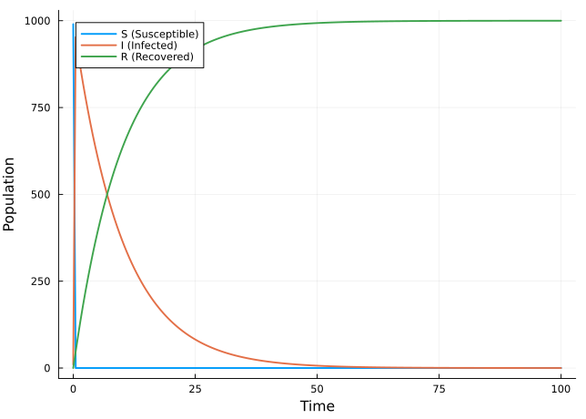

Рисунок 1: Динамика детерминированной модели SIR

На графике наблюдается характерная эпидемическая динамика:

- число восприимчивых уменьшается;
- число инфицированных сначала возрастает;
- количество инфицированных достигает максимума;
- затем число инфицированных снижается;
- количество выздоровевших увеличивается.

# Стохастическая динамика

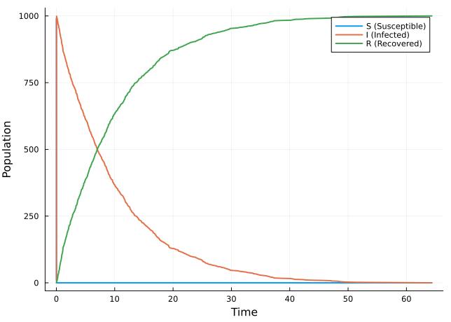

Рисунок 2: Динамика стохастической модели SIR

Стохастическая модель имеет аналогичную общую динамику.

При этом отдельные значения испытывают случайные флуктуации относительно детерминированного поведения.

# Исследование влияния $\beta$

Для исследования влияния коэффициента заражения использовался скрипт:

```
scripts/sirpetri_scan_parameters.jl
```

Была выполнена серия детерминированных экспериментов при различных значениях $\beta$ при фиксированной скорости выздоровления.

Результаты сохраняются в:

```
data/sir_scan.csv
```

# Влияние коэффициента заражения

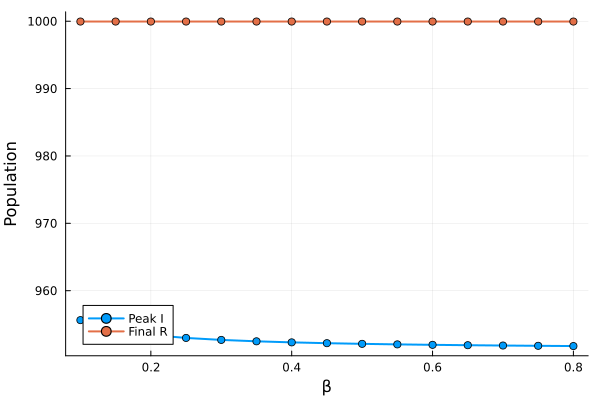

Рисунок 3: Влияние коэффициента заражения β на динамику эпидемии

# Анимация эпидемического процесса

Для визуализации изменения состояния системы во времени использовался скрипт:

```
scripts/sirpetri_animate.jl
```

Результат сохраняется в:

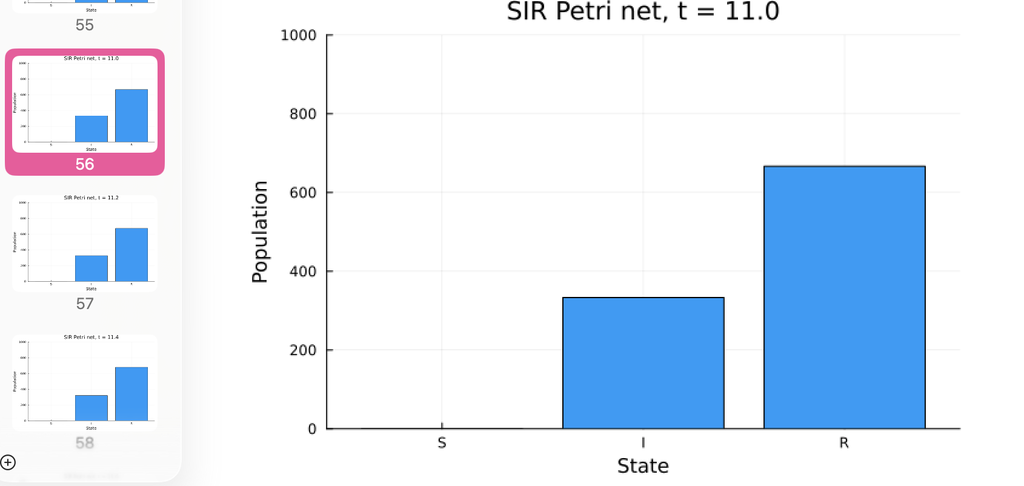

Рисунок 4: Кадр анимации динамики модели SIR

```
plots/sir_animation.gif
```

Анимация позволяет наблюдать изменение трёх групп населения во времени:

- уменьшение числа восприимчивых;
- рост и последующее снижение числа инфицированных;
- увеличение числа выздоровевших.

# Сравнение моделей

Скрипт:

```
scripts/sirpetri_report.jl
```

использует сохранённые результаты моделирования и формирует итоговые графики.

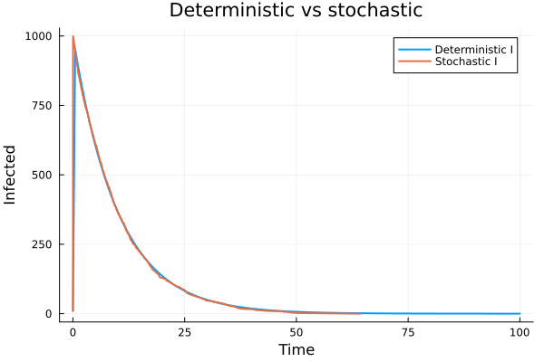

Рисунок 5: Сравнение детерминированной и стохастической моделей SIR

Детерминированная модель задаёт гладкую траекторию.

Стохастическая модель содержит случайные отклонения, однако сохраняет общий характер эпидемической динамики.

# Чувствительность к $\beta$

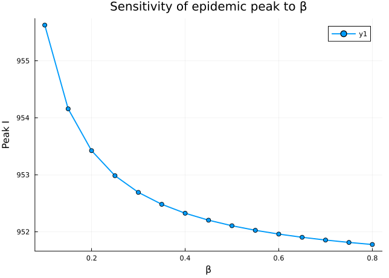

Рисунок 6: Чувствительность максимального числа инфицированных к коэффициенту β

# Параметрическое исследование

Для дополнительного исследования использовался скрипт:

```
scripts/parameterized.jl
```

Он позволяет выполнять моделирование для различных наборов параметров модели.

Результаты параметрического исследования представлены в:

```
notebooks/parameterized.ipynb
```

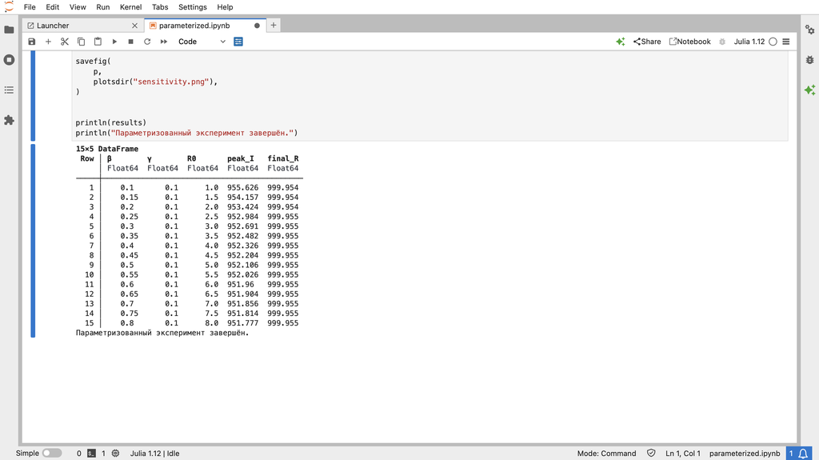

Рисунок 7: Результат выполнения параметризованного эксперимента в Jupyter Notebook

Параметризация позволяет:

- изменять исходные параметры модели;
- выполнять серию экспериментов;
- сравнивать результаты;
- воспроизводить вычислительный эксперимент.

# Литературное программирование

Для оформления исходного кода в литературном стиле был создан файл:

```
scripts/sirpetri_literate.jl
```

Литературное программирование объединяет программный код с поясняющим текстом.

В результате были сформированы:

```
notebooks/sirpetri_literate.ipynb
report/sirpetri_literate.qmd
report/parameterized.qmd
```

Такой подход позволяет одновременно представить алгоритм, его описание и результаты вычислений.

# Структура проекта

Основная структура проекта:

```
project/
├── data/
│   ├── sir_det.csv
│   ├── sir_scan.csv
│   └── sir_stoch.csv
├── notebooks/
│   ├── parameterized.ipynb
│   └── sirpetri_literate.ipynb
├── plots/
│   ├── comparison.png
│   ├── sensitivity.png
│   ├── sir_animation.gif
│   ├── sir_det_dynamics.png
│   ├── sir_scan.png
│   └── sir_stoch_dynamics.png
├── report/
│   ├── parameterized.qmd
│   └── sirpetri_literate.qmd
├── scripts/
│   ├── parameterized.jl
│   ├── sirpetri_animate.jl
│   ├── sirpetri_literate.jl
│   ├── sirpetri_report.jl
│   ├── sirpetri_run.jl
│   └── sirpetri_scan_parameters.jl
└── src/
    └── SIRPetri.jl
```

Такая структура разделяет:

- исходный код;
- данные;
- результаты моделирования;
- документацию;
- Jupyter-ноутбуки.

# Основные результаты

В ходе работы:

- реализована модель SIR на основе сети Петри;
- выполнено детерминированное моделирование;
- выполнено стохастическое моделирование;
- исследовано влияние $\beta$;
- построены графики динамики;
- создана анимация;
- выполнено сравнение моделей;
- проведено параметрическое исследование;
- реализовано литературное программирование;
- созданы Jupyter-ноутбуки и Quarto-документы.

# Выводы

Сети Петри позволяют удобно представлять переходы между состояниями эпидемиологической модели.

Детерминированная и стохастическая модели демонстрируют общий характер распространения инфекции, однако стохастическая модель дополнительно учитывает случайные отклонения.

Параметрическое исследование позволяет воспроизводимо изучать поведение модели при различных исходных условиях.

Литературное программирование объединяет исходный код, пояснения и результаты вычислений в едином представлении.